# Snowshoe Hares

Ian Brunjes

11/20/2020

## 1. Introduction

Snowshoe hares are a keystone prey species in the northern boreal forests of Alaska<sup>1</sup> and therefore represent a vital indicator of overall habitat and population health. A scientific initiative pursued at Bonanza Creek Experimental Forest has yielded insights into several attributes of these hare populations.

This document will provide an exploratory analysis of these observations on snowshoe hares taken in the Tanana Valley from 1999-2012. Specifically, we examine the differences in weight between male and female juvenile snowshoe hares, the relationship between weight and hind foot length, and overall trends in observation counts across the span of the study.

## 2. Data & Analyses

Using summary statistics, 2-sample t-tests, and linear regression modeling, we compare the juvenile weights of male and female snowshoe hares, as well as the relationship between weight and hind foot length.

Data is made available by the Bonanza Creek LTER and the Environmental Data Initiative.<sup>1</sup>

## 3. Exploratory Findings

### 3.1 Juvenile hare trap counts

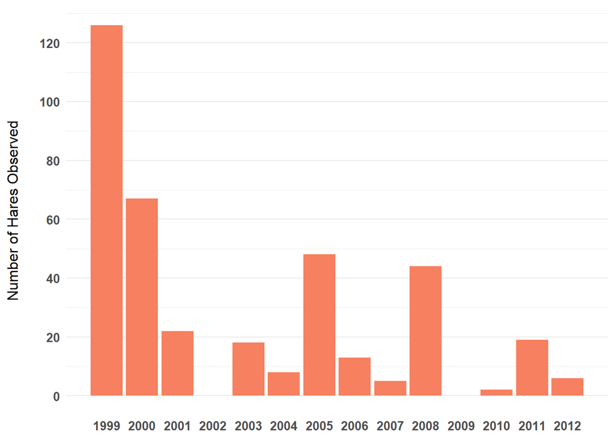

**Figure 3.1.1:** Annual Hare Counts.

There is a general downward trend in the number of hares counted over time. The maximum number of hares (126), observed in the very first year, was much higher than the mean (31.5) or median (18.5) observed across all years. To standardize the hare population estimates based on this count data, I would suggest creating a metric of hares counted per traps set per day. Since the number of traps utilized in each site and number of days visited in a site could skew the number of hares observed to be higher than in other sites.

### 3.2 Juvenile hare weights

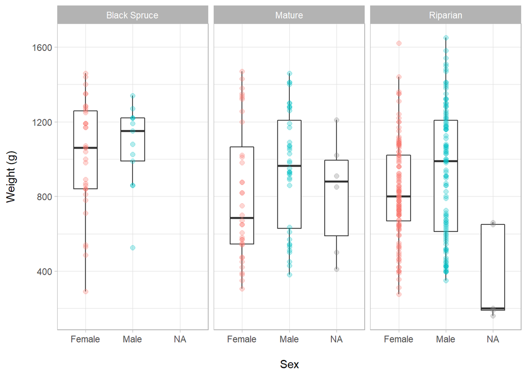

**Figure 3.2.1:** Weight of juvenile hares by sex at each observation site.

The observations of female and male snowshoe hare weight, depicted within each site where they were recorded, shows there is a relative similarity between the weights of the two sexes. From the box plot summary statistics, we can notice that while the median weight for males was higher at each site, the interquartile range of male and female at each site overlap quite a bit.

### 3.3 Juvenile weight comparison

**Table 3.3.1:** Descriptive statistics (mean, median, standard deviation, and sample size) of the weight of juvenile male and female hares.

| Sex | Mean weight (g) | Median weight (g) | Standard deviation (g) | Sample size |
| --- | --- | --- | --- | --- |
| Female | 855.3909 | 825 | 292.2526 | 197 |
| Male | 945.8589 | 990 | 333.2151 | 163 |

From our t-test, we see the mean weight for the male hares is 10.58% higher than mean size for the female group.

If these samples are indeed drawn from populations that have the same mean size (which is our null hypothesis of this t-test), there is a 0.7% chance that two random samples from these populations would result in samples that are at least as different as the ones observed here. What this means is that if there was no difference in weight between male and female samples, there is only a 0.7% chance that a random sampling of this population would result in a difference in mean that is at least as much as we have here.

While the p-value might indicate significance, our effect size is on the small side (Cohen’s *d* = -0.29).

### 3.4 Juvenile weight vs hind foot length

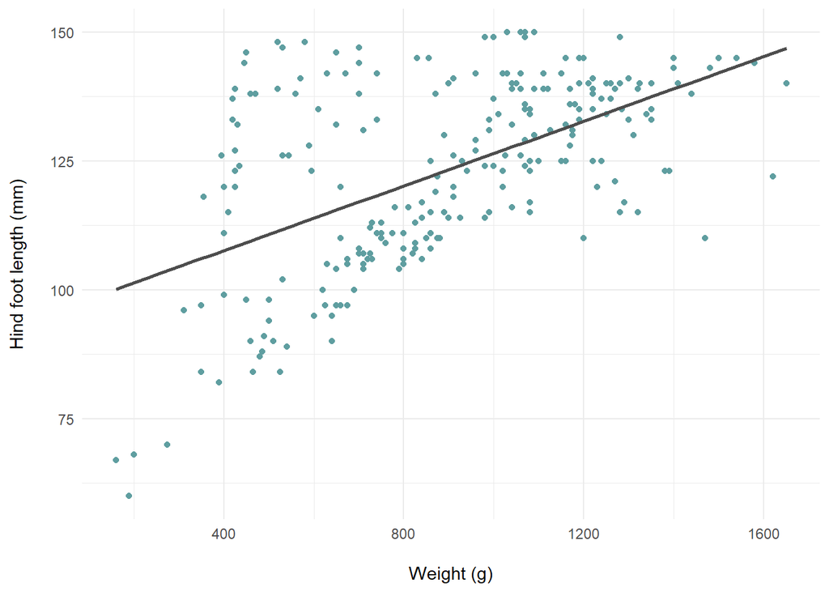

**Figure 3.4.1:** Relationship of weight (g) and hind foot length (mm) in juvenile snowshoe hares.

Checking against the assumptions of linear regression, there is evidence of homoscedastic residuals with no strongly influencing outliers, but there is a concerning trend in lower weight values that might indicate the linear model is not accurately descriptive of the relationship between weight and hind foot length in juvenile snowshoe hares.

## 4. Summary

Exploratory data analysis reveals the following initial findings:

- There is a decrease in snowshoe hare population being observed from 1999 - 2012.
- In juvenile snowshoe hares, males are observed to have higher weights than females (the difference is significant, and the effect size is small).
- In juvenile snowshoe hares, Weight appears linearly related with hind foot length; the relationship (by simple linear regression) is significant, with a slope (expected average increase in hind foot length with a 1 g increase in weight) of 0.03 mm g<sup>-1</sup>.

## 5. Citations

<sup>1</sup>**Kielland, K., F.S. Chapin, R.W. Ruess, and Bonanza Creek LTER.** 2017. Snowshoe hare physical data in Bonanza Creek Experimental Forest: 1999-Present ver 22. Environmental Data Initiative. https://doi.org/10.6073/pasta/03dce4856d79b91557d8e6ce2cbcdc14